# Grundlagen Hierarchischer Bayesianischer-Modelle

Formalisierung induktiver Biases am Beispiel des Kategorienlernens

Jan Luca Schnatz  
Martikelnummer: 7518898

# Hierarchisches Beta-Binomiales Modell

## Einführendes Beispiel

Wiederholtes Ziehen von schwarzen und weißen Murmeln aus verschiedenen Murmelbeuteln

[figure not shown]

Welche Farbe ist für die nächste Murmel im achten Murmelbeutel am wahrscheinlichsten?

## Intuition

- Eine einzelne schwarze Murmel liefert wenig Information über zukünftige Murmeln.
- Durch Vorwissen über viele Murmelbeutel (meist schwarz oder meist weiß) wird die einzelne Beobachtung informativ.

$\rightarrow$ Hohe Wahrscheinlichkeit, dass die nächsten Murmeln ebenfalls schwarz sind

**Hierarchische Struktur**

- Informationen werden über Murmelbeutel hinweg auf höherer Ebene geteilt.
- Beobachtungen aus früheren Murmelbeuteln formen starke Priors.
- Diese Priors beeinflussen Vorhersagen über neue Murmelbeutel.

**Zielsetzung**

Entwicklung eines Bayesianisches-Modell, das menschliche Schlussfolgerung über Farbverteilungen zwischen Murmelbeuteln rekonstruiert kann (*reverse-engineering*).

## Formalisierung des Problems

Wir ziehen aus $i$ Murmelbeuteln, wobei $y_i$ die Anzahl an gezogenen schwarzen Murmel und $n_i$ die ingesamt gezogenen Murmeln repräsentiert.

## Formalisierung des Problems

Wir ziehen aus $i$ Murmelbeuteln, wobei $y_i$ die Anzahl an gezogenen schwarzen Murmel und $n_i$ die ingesamt gezogenen Murmeln repräsentiert.

**Level 1 – Daten**

$d_i: \big\{y_i, n_i \big\}$

[figure not shown]

## Formalisierung des Problems

Wir ziehen aus $i$ Murmelbeuteln, wobei $y_i$ die Anzahl an gezogenen schwarzen Murmel und $n_i$ die ingesamt gezogenen Murmeln repräsentiert.

**Level 1 – Daten**

$d_i: \big\{y_i, n_i \big\}$

**Level 2 – Beutelspezifische Verteilung**

$y_i ~ \big| ~ n_i \sim \text{Binom}(\theta_i)$

## Formalisierung des Problems

Wir ziehen aus $i$ Murmelbeuteln, wobei $y_i$ die Anzahl an gezogenen schwarzen Murmel und $n_i$ die ingesamt gezogenen Murmeln repräsentiert.

**Level 1 – Daten**

$d_i: \big\{y_i, n_i \big\}$

**Level 2 – Beutelspezifische Verteilung**

- $\theta_i$: Wahrscheinlichkeit, eine schwarze Murmel aus Beutel $i$ zu ziehen
- Verschiedene Beutel können unterschiedliche Wahrscheinlichkeiten $\theta_i$ haben

$y_i ~ \big| ~ n_i \sim \text{Binom}(\theta_i)$

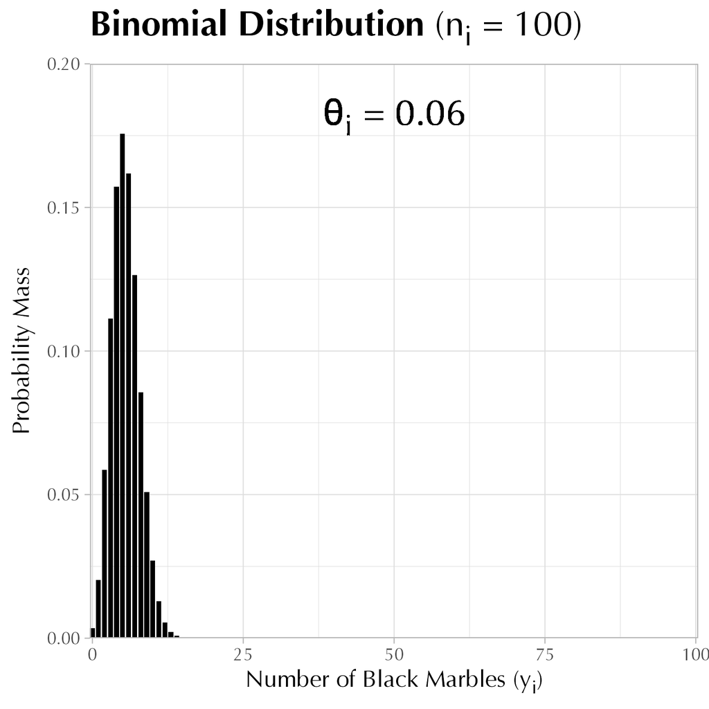

## Formalisierung des Problems

Wir ziehen aus $i$ Murmelbeuteln, wobei $y_i$ die Anzahl an gezogenen schwarzen Murmel und $n_i$ die ingesamt gezogenen Murmeln repräsentiert.

**Level 1 – Daten**

$d_i: \big\{y_i, n_i \big\}$

**Level 2 – Beutelspezifische Verteilung**

$y_i ~ \big| ~ n_i \sim \text{Binom}(\theta_i)$

**Level 3 – Allgemeines Wissen über Murmelbeutel**

$\theta_i \sim \text{Beta}(\alpha, \beta)$

## Formalisierung des Problems

Wir ziehen aus $i$ Murmelbeuteln, wobei $y_i$ die Anzahl an gezogenen schwarzen Murmel und $n_i$ die ingesamt gezogenen Murmeln repräsentiert.

**Level 1 – Daten**

$d_i: \big\{y_i, n_i \big\}$

**Level 2 – Beutelspezifische Verteilung**

$y_i ~ \big| ~ n_i \sim \text{Binom}(\theta_i)$

**Level 3 – Allgemeines Wissen über Murmelbeutel**

- Mittlere Wahrscheinlichkeit ($\frac{\alpha}{\alpha + \beta}$) eine schwarze Kugel zu ziehen über die Population von Beuteln
- Precision-Paramter ($\alpha + \beta$) beschreibt die Konzentration der Wahrscheinlichkeitsmasse um den Mittelwert (invers zur Varianz)

$\theta_i \sim \text{Beta}(\alpha, \beta)$

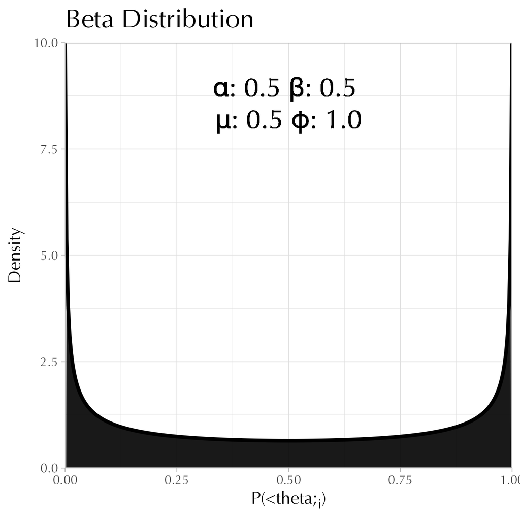

## Formalisierung des Problems

Wir ziehen aus $i$ Murmelbeuteln, wobei $y_i$ die Anzahl an gezogenen schwarzen Murmel und $n_i$ die ingesamt gezogenen Murmeln repräsentiert.

**Level 1 – Daten**

$d_i: \big\{y_i, n_i \big\}$

**Level 2 – Beutelspezifische Verteilung**

$y_i ~ \big| ~ n_i \sim \text{Binom}(\theta_i)$

**Level 3 – Allgemeines Wissen über Murmelbeutel**

$\theta_i \sim \text{Beta}(\alpha, \beta)$

**Level 4 – Hyperparameter**

$\frac{\alpha}{\alpha + \beta} \sim \text{Unif}(0, 1)$

$\alpha + \beta \sim \text{Exp}(1)$

## Formalisierung des Problems

Wir ziehen aus $i$ Murmelbeuteln, wobei $y_i$ die Anzahl an gezogenen schwarzen Murmel und $n_i$ die ingesamt gezogenen Murmeln repräsentiert.

**Level 1 – Daten**

$d_i: \big\{y_i, n_i \big\}$

**Level 2 – Beutelspezifische Verteilung**

$y_i ~ \big| ~ n_i \sim \text{Binom}(\theta_i)$

**Level 3 – Allgemeines Wissen über Murmelbeutel**

$\theta_i \sim \text{Beta}(\alpha, \beta)$

**Level 4 – Hyperparameter**

- Prior der Beta-Verteilung
- Uniformer Prior für ($\frac{\alpha}{\alpha + \beta}$) $\rightarrow$ jede mittlere Wahrscheinlichkeit, eine schwarze Murmel zu ziehen gleich wahrscheinlich
- Exponentielle Verteilung für ($\alpha + \beta$) $\rightarrow$ kleinere Werte wahrscheinlicher (Tendenz zur Homogenität innerhalb der Beutel)

$\frac{\alpha}{\alpha + \beta} \sim \text{Unif}(0, 1)$

$\alpha + \beta \sim \text{Exp}(1)$

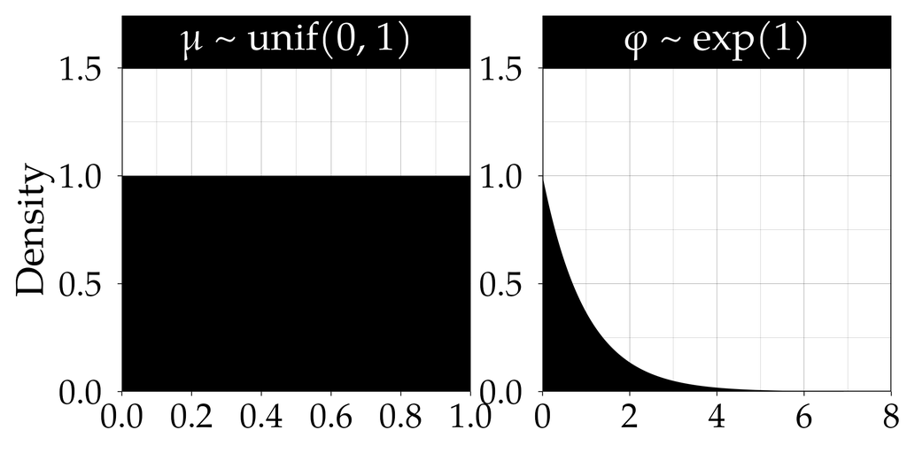

## Formalisierung des Problems

Wir ziehen aus $i$ Murmelbeuteln, wobei $y_i$ die Anzahl an gezogenen schwarzen Murmel und $n_i$ die ingesamt gezogenen Murmeln repräsentiert.

**Level 1 – Daten**

$d_i: \big\{y_i, n_i \big\}$

**Level 2 – Beutelspezifische Verteilung**

$y_i ~ \big| ~ n_i \sim \text{Binom}(\theta_i)$

**Level 3 – Allgemeines Wissen über Murmelbeutel**

$\theta_i \sim \text{Beta}(\alpha, \beta)$

**Level 4 – Hyperparameter**

$\frac{\alpha}{\alpha + \beta} \sim \text{Unif}(0, 1)$

$\alpha + \beta \sim \text{Exp}(1)$

## Posteriore Inferenz

Anwendung von Bayes-Formel bei hierarchischen Modellen (Gelman, 2014)

$$\begin{gathered}
\overbrace{P(\theta, \alpha, \beta ~ | ~ y)}^{\text{Posterior}} \propto
\underbrace{P(\alpha, \beta)}_{\text{Hyperprior}} \overbrace{P(\theta ~ | ~ \alpha, \beta)}^{\text{Conditional Prior}} \underbrace{P(y ~ | ~ \theta, \alpha, \beta)}_{\text{Likelihood}}
\end{gathered}$$

Posterior Inferenz bezüglich $\theta_i$ durch Integration über $\alpha$ und $\beta$ (Griffiths et al., 2024)

$$\begin{align*}
P(\theta_i ~ | ~ d_1, \dots, d_n) =
\iint P(\theta_i ~ | ~ \alpha, \beta, d_i) P(\alpha, \beta ~ | ~ d_1, \dots, d_n) \,d\alpha \,d \beta
\end{align*}$$

## Anwendung des Modells auf das Murmelbeispiel

- Szenario 1
- Szenario 2

[figure not shown]

## Zwischenfazit

Das Murmelbeispiel zeigt, dass HBMs gut mit unserer Intuition übereinstimmen, wie hierarchisch strukturierte Daten genutzt werden können, um Generalisierungen (*overhypotheses*) zu bilden.

*Wieso ist das wichtig?*

Diese Abstrakte Wissen ermöglicht schnelles Lernen aus nur wenigen Daten sowie *One-Shot-Generalisierung*.

# Anwendung von HBMs to *Lernen von Kategorien*

[figure not shown]

## Einführendes Beispiel

[figure not shown]

Szenario: Eine Mutter zeigt auf einen unbekannten Gegenstand und sagt zu ihrem Kind, dass dies ein *Stift* sei.

**Frage**

Anhand welcher Merkmale verallgemeinern Kinder das Konzept „Stift“ und erkennen zukünftige Exemplare eines Stifts als solchen an?

- Grundsätzlich könnte das Kind das Wort auf Objekte mit *gleichem Material*, *gleicher Farbe*, *gleicher Textur* oder einfach *Objekten auf der Arbeitsplatte* übertragen.
- Empirisch neigen Kinder jedoch dazu, das neue Wort auf andere Objekte zu übertragen, die die **gleiche Form** haben.

**Shape Bias**

Die Erwartung, dass Mitglieder einer Kategorie tendenziell eine ähnliche Form haben.

## Adapation des Hierarchischen Beta-Binomialen Modells

Übersicht der Modeladaptionen

|  | Murmel-Beispiel | Form-Beispiel |
| --- | --- | --- |
| Hierarchisch Variable | Beutel | Objektkategorie |
| Daten | Murmel | Exemplare |
| Merkmale | Farbe | Form, Farbe, Textur, Größe, etc. |
| Merkmalswerte | Binär | Kategorisch |

Nach Kemp et al. (2007):

- **Level 1**: Binäre Beobachtungen $\rightarrow$ Kategoriale Beobachtungen
- **Level 2**: Binomialverteilung $\rightarrow$ Multinomialverteilung
- **Level 3**: Beta-Prior $\rightarrow$ Dirichlet-Prior
- **Level 4**: Hyperprior wie zuvor
- Kopie von Level 2–4 **für jede Merkmalsdimension** (Farbe, Form, Textur, Größe)

## Model Adaption

- Das Modell schließt, dass Kategorien in der **Form konsistent** sind (geringe Varianz), aber in der **Farbe variabel** (hohe Varianz)
- Diese gelernte Struktur erzeugt eine **starke Prior-Erwartung**, dass jede neue Kategorie ebenfalls in der Form homogen ist
- Modell **schnelle Generalisierung** neuer Labels basierend auf **Formähnlichkeit** und ignoriert effektiv Unterschiede in der Farbe $\rightarrow$ Shape Bias

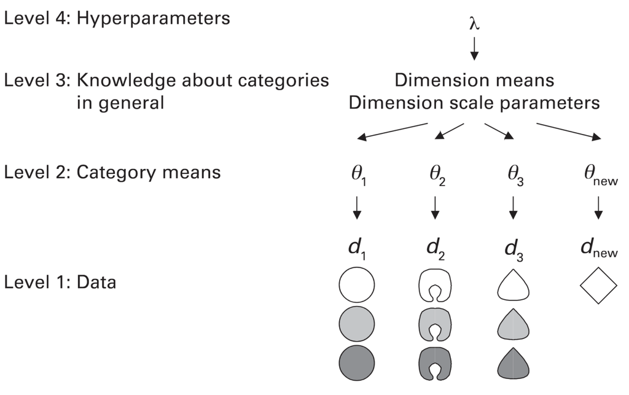

## Anwendung auf die Nomen-Generalisation

Table 1: Training Data

|  | 1 |  | 2 |  | 3 |  | 4 |  |
| --- | --- | --- | --- | --- | --- | --- | --- | --- |
| Kategorie | 1 | 1 | 2 | 2 | 3 | 3 | 4 | 4 |
| Form | 1 | 1 | 2 | 2 | 3 | 3 | 4 | 4 |
| Textur | 1 | 2 | 3 | 4 | 5 | 6 | 7 | 8 |
| Farbe | 1 | 2 | 3 | 4 | 5 | 6 | 7 | 8 |
| Größe | 1 | 2 | 1 | 2 | 1 | 2 | 1 | 2 |

- Zwei Exemplare pro Kategorie (Spalten)
- Verschiedene Merkmalsdimensionen (Form, Textur, Farbe, Größe)
- Paare von Objekten derselben Kategorie teilen die gleiche Form

Table 2: Testing Data

|  | 'Dax' | Objekt 1 | Objekt 2 | Objekt 3 |
| --- | --- | --- | --- | --- |
| Kategorie | 5 | ? | ? | ? |
| Form | 5 | 5 | 6 | 6 |
| Textur | 9 | 10 | 9 | 10 |
| Farbe | 9 | 10 | 10 | 9 |
| Größe | 1 | 1 | 1 | 1 |

Nach dem Training stoßen Kinder (und das Modell) auf ein neues Objekt mit dem neuen Nomen *„dax“*.

**Aufgabe:** Welches der drei Kandidatenobjekte mit unbekannter Kategorie ist am wahrscheinlichsten ein *dax*?

Basierend auf Daten von Smith et al. (2002)

## Ergebnisse

- 19 Monate alte Kinder, die das strukturierte Training erhielten, wählen das Objekt mit **gleicher Form** $\rightarrow$ Shape Bias
- Untrainierte 19 Monate alte Kinder wählen **zufällig**
- HBM weist gleichen **Präferenzmuster wie die trainierten Kinder** auf

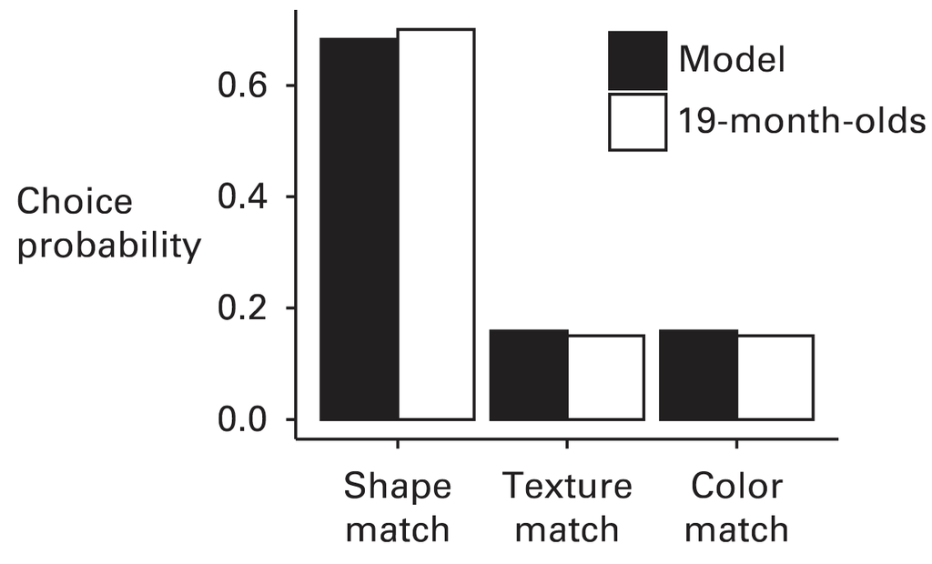

## Take Home Message

Hierarchische Bayes-Modelle zeigen, dass **induktive Biases** (wie der Shape Bias) nicht angeboren sein müssen, sondern aus der statistischen **Struktur** der Umwelt gelernt werden können.

## Literatur

Gelman, A. (2014). *Bayesian Data Analysis* (3rd ed.). Chapman & Hall/CRC.

Griffiths, T. L., Chater, N., & Tenenbaum, J. (2024). *Bayesian Models of Cognition: Reverse Engineering the Mind*. MIT Press. https://mitpress.mit.edu/9780262049412/bayesian-models-of-cognition/

Kemp, C., Perfors, A., & Tenenbaum, J. B. (2007). Learning overhypotheses with hierarchical Bayesian models. *Developmental Science*, *10*(3), 307–321. https://onlinelibrary.wiley.com/doi/abs/10.1111/j.1467-7687.2007.00585.x

Smith, L. B., Jones, S. S., Landau, B., Gershkoff-Stowe, L., & Samuelson, L. (2002). Object name learning provides on-the-job training for attention. *Psychological Science*, *13*(1), 13–19. https://doi.org/10.1111/1467-9280.00403